# Analysis of absolute bacterial abundances.

This notebook describes how we link bacterial 16S ASV counts with absolute abundances via quantifying the relationship between host- vs. non-host-derived ASV counts. We first establish the highly repeatable relationship between insect herbivory and density of culturable bacteria (CFU g$^{-1}$ leaf tissue) for a sub-set of our samples that were cultured in parallel to 16S sequencing. We then estimate a model that allows us to generate predictive posterior distributions of how host-derived ASV counts relates to bacterial density so we can generate such predictions across the entire sample set. Sections of this notebook are exported to generate Fig. 1 of the main text.

First we load the standard header for this project:

```r
#header
library(here)
source(here("scripts/phy_header.R"))
source(here("scripts/phy_functions.R"))
```

Now we need to load the ASV hit tables and the affiliated sample data containig the covariates for our models:

```r
#ASV.path <- "/Users/phumph/Dropbox/Phyllosphere_project/analysis_phy/16S_seq/"
#data.path <- "/Users/phumph/Dropbox/Phyllosphere_project/analysis_phy/data/"
ASV.path <- here("../16S_seq/")
data.path <- here("data/")
ASVs <- read.csv(file = paste0(ASV.path,"ASV_table_final.csv"), row.names = 1)
mEL  <- read.csv(file = paste0(data.path,"EL_sample_data_final.csv"), row.names = 1)
mNP  <- read.csv(file = paste0(data.path,"NP_sample_data_final.csv"), row.names = 1)
```

Let’s split the ASV table by dataset and add in the sample metadata:

```r
# remove bASVs from Families putatively introduced via library or sample cross-contamination:
fams_to_remove <- c('Enterobacteriaceae')

# load correspondng bTAX file with bASV unique identifiers:

# add column that sums up all reads as well a host-derived reads:
ASVs[,'lib']  <- rowSums(ASVs)
ASVs[,'host'] <- rowSums(ASVs[,names(ASVs) %in% c("mt","cp")])
ASVs[,'bac']  <- rowSums(ASVs[,1:(length(ASVs[1,])-5)])

# sanity check these sum up to 'lib'
#ASVs[,'bac'] + ASVs[,'fungi'] + ASVs[,'host'] == ASVs[,'lib'] # yup. checks out. I can add.

ELD <- merge(ASVs, mEL, by = "row.names")
NPD <- merge(ASVs, mNP, by = "row.names")

# grab subset of rows where logLeafCFU>0:
ELc <- ELD[complete.cases(ELD[,'logLeafCFU']),]
```

Let’s take a look at the relationship between host-derived sequences and culturable bacteria from paired leaf samples:

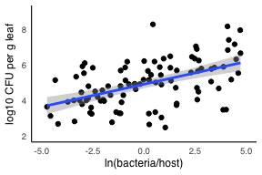

As a sanity check, let’s inspect the relationship between chloroplast (cp) and mitochondria (mt) host-derived counts:

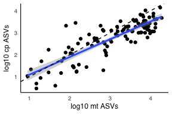

```r
ggplot(ELc, aes(x = log(cp,10), y = log(mt,10))) +
  geom_point() +
  xlab("log10 mt ASVs") +
  ylab("log10 cp ASVs") +
  stat_smooth(method = "lm") +
  geom_abline(slope = 1, intercept = 0, col = "black", lty = "dashed") + theme_phy1()
```

Finally, let’s inspect the relationship between herbivore damage and $\text{log CFU} g^{-1}$ leaf in the reduced dataset, as well as $\text{log} (\text{bacteria}/\text{host})$ 16S reads in the full datasets:

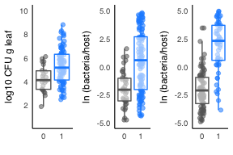

```r
#CFU plot:
cfu1 <- ggplot(ELc, aes(y = logLeafCFU, x = factor(herb_dmg), col = factor(herb_dmg),alpha = 0.2)) +
  geom_jitter(width = 0.15) + xlab("") +
  # stat_summary(geom = "crossbar",
  # fun.ymin = function(z) { quantile(z,0.25) },
  # fun.ymax = function(z) { quantile(z,0.75) },
  # fun.y = median,
  # size = 0.2) +
  geom_boxplot(width = 0.8) +
  ylab("log10 CFU g leaf") +
  scale_y_continuous(limits = c(0.5,10), breaks = seq(2,10,2)) +
  scale_color_manual(values = c("gray40","dodgerblue")) +
  theme_phy1() + theme(legend.position = "none")
hp1 <- ggplot(ELD, aes(y = log(bac/host), x = factor(herb_dmg), col = factor(herb_dmg), alpha = 0.2)) +
  geom_jitter(width = 0.15) + xlab("") +
  # stat_summary(geom = "crossbar",
  # fun.ymin = function(z) { quantile(z,0.25) },
  # fun.ymax = function(z) { quantile(z,0.75) },
  # fun.y = median,
  # size = 0.2) +
  geom_boxplot(width = 0.8) +
  ylab("ln (bacteria/host)") +
  ylim(values = c(-5,5)) +
  scale_color_manual(values = c("gray40","dodgerblue")) +
  theme_phy1() + theme(legend.position = "none")
hp2 <- ggplot(NPD, aes(y = log(bac/host), x = factor(herb_dmg), col = factor(herb_dmg), alpha = 0.2)) +
  geom_jitter(width = 0.15) + xlab("") +
  # stat_summary(geom = "crossbar",
  # fun.ymin = function(z) { quantile(z,0.25) },
  # fun.ymax = function(z) { quantile(z,0.75) },
  # fun.y = median,
  # size= 0.2) +
  ylab("ln (bacteria/host)") +
  ylim(values = c(-5,5)) +
  geom_boxplot(width = 0.8) +
  scale_color_manual(values = c("gray40","dodgerblue")) +
  theme_phy1() + theme(legend.position = "none")

#grid.arrange(cfu1, hp1, hp2, ncol=3)
ggarrange(plotlist = list(cfu1,hp1,hp2), ncol = 3)
```

Perform posterior predictions for Bayesian model of ln(bac/host) vs. logLeafCFU from Gaussian regression model:

```r
# run Bayesian model using Stan via brmns
library(brms)

ELc[,'ln_bac_host'] <- log(ELc[,'bac']/ELc[,'host'])

# estimate model
cfu_m1 <- brm(bf(logLeafCFU ~ ln_bac_host),
               family = gaussian(),
               data = ELc,
               control = list(adapt_delta = 0.99))

# save model for later importing
saveRDS(cfu_m1, file = here("models/cfu_m1.rds"))

#summary(cfu_m1)
# feed full data into predictive posterior sampling for cfu_m1 model:
# capture distribution of 1000 medians of simulated distributions; over-plot onto a sigle example:

# steps:
# make function with inputs:
  # newdat (same shape as ELD and NPD)
  # S for num sim
  # ppstat = statistic to calculate on yrep^S per factor level (in this case, herb_dmg)
  # ppfact = factor on which to calculate the ppstat. posterior predictions in this case need not marginalize over any group terms, since there aren't any.

ppsim <- function(mod, nd, ppstat = "mean", ppfact = "herb_dmg", S){
  require(dplyr)
  # define factor levels
  ppfact_levels <- levels(nd[,paste0(ppfact)])
  # create results matrix of correct dimensions
  Sres <- data.frame()
  # perform simulations and summary statisics
  for (s in 1:S){
    yrep <- posterior_predict(mod, newdat = nd, nsamples = 1) # generate samples
    Sres <- rbind(Sres,data.frame(dplyr::group_by(data.frame(yrep = t(yrep), ppfact = nd[,ppfact]), ppfact) %>% summarise(yrep = log(mean(10^yrep),10)), s))
  }

  yrep <- data.frame(ppfact = nd[,ppfact],yrep = t(yrep), s = s, grp = 'sim')
  Sres[,'grp'] <- 'means'

  return(list(Y0 = yrep, Y1 = Sres))
  #return(rbind(Sres,yrep))
}

ELD[,'ln_bac_host'] <- log(ELD[,'bac']/ELD[,'host'])
NPD[,'ln_bac_host'] <- log(NPD[,'bac']/NPD[,'host'])

# EL data
nd1 <- ELD[,names(ELD) %in% c('sample','ln_bac_host','herb_dmg')]
nd1[,'herb_dmg'] <- factor(nd1[,'herb_dmg'])

# NP data
nd2 <- NPD[,names(NPD) %in% c('sample','ln_bac_host','herb_dmg')]
nd2[,'herb_dmg'] <- factor(nd2[,'herb_dmg'])

# run posterior predictive simulations
CFU_Yrep1 <- ppsim(mod = cfu_m1, nd = nd1, ppstat = 'mean', ppfact = 'herb_dmg', S=100)
CFU_Yrep2 <- ppsim(mod = cfu_m1, nd = nd2, ppstat = 'mean', ppfact = 'herb_dmg', S=100)

# make combined file for
YREPS <- rbind(data.frame(CFU_Yrep1[[1]], dataset = 'EL'), data.frame(CFU_Yrep2[[1]], dataset = 'NP'))
MEANS <- rbind(data.frame(CFU_Yrep1[[2]], dataset = 'EL'), data.frame(CFU_Yrep2[[2]], dataset = 'NP'))
```

Let’s re-draw this by facetting on dataset:

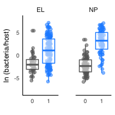

Plotting posterior predicted log CFU per g leaf:

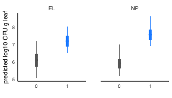

Let’s make the linear regression plot a little better. We will add quartile envelopes for the span of the x axis, generated from simulated data:

```r
# generate simulated data and grab quantiles to plot
# model object: cfu_m1
cfu_env <- posterior_predict(cfu_m1, newdat = data.frame(ln_bac_host = seq(-5,5,by = 0.1)), S = 1000)

# grab first 1000 sims
cfu_env2 <- data.frame(t(cfu_env[1:1000,]))

# rows are sims, cols are data points
cfu_env2[,'ln_bac_host'] <- seq(-5,5,by = 0.1)
# extract quantiles
cfu_env2[,'p2.5']  <- apply(cfu_env2, 1, function(x) quantile(x, probs = c(0.025)))
cfu_env2[,'p25']   <- apply(cfu_env2, 1, function(x) quantile(x, probs = c(0.25)))
cfu_env2[,'p50']   <- apply(cfu_env2, 1, function(x) quantile(x, probs = c(0.5)))
cfu_env2[,'p75']   <- apply(cfu_env2, 1, function(x) quantile(x, probs = c(0.75)))
cfu_env2[,'p97.5'] <- apply(cfu_env2, 1, function(x) quantile(x, probs = c(0.975)))

# remove yrep sim values
cfu_env2 <- cfu_env2[,-c(1:1000)]
```

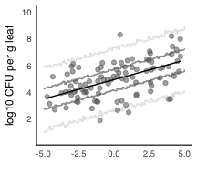

Now let’s look to see whether un-damaged leaves in the same sub-plot as damaged leaves have residually higher bacterial burdens, as would be expected if some underlying susceptibility were at play here, perhaps making leaves jointly susceptible to bacteria and herbivory. Alternatively, if bacteria occur first and increase risk of herbivory, then sampling variation by herbivores should leave many highly infected leaves without herbivory just by chance.

We will use both EL and NPB data-sets to get at this

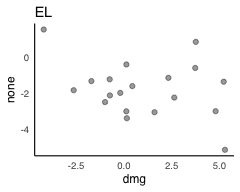

Trying with NP:

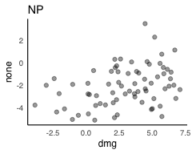

There is quite possibly a relationship here, with un-damaged leaf sets collected from the same sub-plots as damaged leaves with higher abundance showing a trend towards bacterial enrichment. This indicates some kind of shared susceptibility OR systemic induced susceptibility. This pattern is not found in the EL dataset, but the leaves were collected randomly without respect to leaf damage. In other words, there was no explicit matching by sub-plot ID `sp_id`.

I need to calcualte the 95% credible interval for the ICC of `sp_id`, which should give me similar information, after taking into account the effect of herb_dmg. But first, let’s see if there is anything to be seen with this hormone analysis. First, we should take a look at whether hormone treatments impact bacterial abundances as measured by our log ratio:

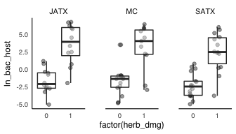

We will explicitly test for an effect of SA treatment on bacterial abundance below:

```r
summary(mod1)
```

```
 Family: gaussian  ( identity )
Formula:          ln_bac_host ~ herb_dmg + stem_tx + (1 | plot_num) + (1 | sp_id)
Data: NPD[NPD$sub_plot_tx == "TX", ]

     AIC      BIC   logLik deviance df.resid
   373.3    390.0   -179.7    359.3       73

Random effects:

Conditional model:
 Groups   Name        Variance Std.Dev.
 plot_num (Intercept) 0.7269   0.8526
 sp_id    (Intercept) 0.7269   0.8526
 Residual             3.9621   1.9905
Number of obs: 80, groups:  plot_num, 42; sp_id, 42

Dispersion estimate for gaussian family (sigma^2): 3.96

Conditional model:
            Estimate Std. Error z value Pr(>|z|)
(Intercept)  -1.6038     0.5808  -2.761  0.00576 **
herb_dmg      4.9799     0.4520  11.017  < 2e-16 ***
stem_txMC    -0.2863     0.7477  -0.383  0.70178
stem_txSATX  -0.8679     0.7092  -1.224  0.22105
---
Signif. codes:  0 ‘***’ 0.001 ‘**’ 0.01 ‘*’ 0.05 ‘.’ 0.1 ‘ ’ 1
```

```r
ICtab(mod1,mod2,mod3,mod4,mod5, type = "AICc")
```

```
     dAICc df
mod5 0.0   6
mod3 5.1   6
mod2 5.1   6
mod4 5.7   5
mod1 7.5   7
```

Very clearly the best model contains two residual error terms, one for un-damaged and the other for damaged leaves, with variance being greater in the latter.

### THIS IS WHERE THIS FILE SHOULD END

Moving backwards..

The next step is to dive into the bacterial taxonomy a bit and ask whether different families exhibit similar or dissimilar variation among damaged versus un-damaged leaves. To do this, we will load up our bacterial taxa and ASV count tables and partition them depending on membership in the EL and/or NB datasets. Then we will construct Family-level models for all families whose summed abundance is $\geq 1\%$ of the dataset. We will plot these and define our cutoffs for both abundance and prevalence.

First, let’s make sure we have the right bacterial ASV data loaded:

```r
ASV8 <- read.csv(here("data/ASV_table_final.csv"))
bTAX4 <- read.csv(here("data/bTAX_table_final.csv"))

bTAX4 <- bTAX4[bTAX4$Kingdom != "Eukaryota",]

bTAX4$rel <- bTAX4$total / sum(bTAX4$total)

# define set that is present in EL
bTAX4$in_EL <- 0
bTAX4$in_EL[bTAX4$unique.id %in% names(ELD)] <- 1

# define set that is present in NB
bTAX4$in_NP <- 0
bTAX4$in_NP[bTAX4$unique.id %in% names(NPD)] <- 1
```

```r
bTAX5 <-  bTAX4[bTAX4$in_EL > 0, ]
bTAX6 <- bTAX4[bTAX4$in_NP > 0, ]
```

Let’s define our prevalence and abundance measures for each ASV in both data-sets. This will allow us to determine the correlation between the datasets as well as determine our abundance cutoffs for Family-level models.

```r
ELD_sums <- colSums(ELD[,names(ELD) %in% bTAX5$unique.id]) # abundance
ELD_sums <- ELD_sums / sum(ELD_sums) # convert to relative abundance

NPD_sums <- colSums(NPD[,names(NPD) %in% bTAX5$unique.id]) # abundance
NPD_sums <- NPD_sums / sum(NPD_sums) # convert to relative abundance

# now for prevalence. need to comvery numeric matrix to binary
ELDb <- ELD[,names(ELD) %in% bTAX5$unique.id]
ELDb[ELDb>0] <- 1

NPDb <- NPD[,names(NPD) %in% bTAX5$unique.id]
NPDb[NPDb>0] <- 1

ELD_prev <- colSums(ELDb) / length(ELDb[,1])
NPD_prev <- colSums(NPDb) / length(NPDb[,1])

abund_prev <- data.frame(ELD_sums, NPD_sums, ELD_prev, NPD_prev)
abund_prev$unique.id <- row.names(abund_prev)

# add taxonomic information from bTAX5
abund_prev <- merge(abund_prev, bTAX5, by = "unique.id", sort = F)
abund_prev <- abund_prev[order(abund_prev$ELD_sums, decreasing = TRUE),]
```

Now we can look at abundance versus prevalence for each unique ASV across the two datasets:

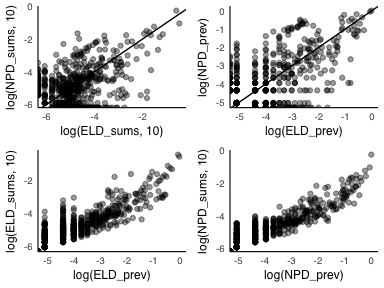

Now we will group them by Family and re-plot:

```r
names(abund_prev)[1] <- 'unique.id'
abund_prev <- merge(abund_prev, data.frame(ELD_abs = colSums(ELD[,names(ELD) %in% bTAX5$unique.id]),
                                           NPD_abs = colSums(NPD[,names(NPD) %in% bTAX5$unique.id]),
                                           ELD_prev2 = colSums(ELDb),
                                           NPD_prev2 = colSums(NPDb)
                                           ),
                    by.x = 'unique.id', by.y = "row.names", sort = F, all.x = TRUE, all.y = FALSE)
# using dplyr
abund_prev2 <- group_by(abund_prev, Family) %>% summarise(EL_tot = sum(ELD_abs),
                                                          NP_tot = sum(NPD_abs),
                                                          tot = sum(EL_tot,NP_tot)) %>% arrange(desc(tot))

# take columns matching Family; calculate row totals; then convert to binary and calculate colSums. This, as a proportion of number of leaves, is family-level prevalence.
# add prevalence information
# NOT DONE:
x <- ELD
y <- abund_prev
# take all Families that are represented above 10^-4 in the dataset:
abund_prev2$rel_abund <- abund_prev2$tot/sum(abund_prev2$tot)

# define list of all families that have more than 10 reads across dataset:
fams <- unique(abund_prev2$Family)

# remove NA value, which is waste bin of all non-classified sequences.
fams <- fams[!is.na(fams)]

# function that calculates prevalence of sets of bASVs, indexed by unique.id, across the dataset
family_prev <- function(x,y,fams){
  fams2 <- NULL
  for (s in 1:length(fams)){
    focal_asvs <- y$unique.id[y$Family %in% paste0(fams[s])]
    tmp_df <- x[,names(x) %in% focal_asvs]
    if(length(focal_asvs) < 2){
      new_df <- data.frame(fam_tot = tmp_df, herb_dmg = x$herb_dmg)
      new_df$fam_tot[new_df$fam_tot > 0] <- 1 # re-assign to binary for prevalence calculation
      new_df2 <- group_by(new_df, herb_dmg) %>% summarise(hits = sum(fam_tot), N = length(herb_dmg), prev = hits/N)
    } else{
      #new_sums <- rowSums(tmp_df)
      new_df <- data.frame(fam_tot = rowSums(tmp_df),herb_dmg = x$herb_dmg)
      new_df$fam_tot[new_df$fam_tot > 0] <- 1 # re-assign to binary for prevalence calculation
      new_df2 <- group_by(new_df, herb_dmg) %>% summarise(hits = sum(fam_tot), N = length(herb_dmg), prev = hits/N)
    }
    fams2 <- rbind(fams2,data.frame(Family = paste0(fams[s]), new_df2))
  }
  return(fams2)
}

EL_fam_prev <- family_prev(x = ELD, y = bTAX5, fams = fams)
NP_fam_prev <- family_prev(x = NPD, y = bTAX6, fams = fams)
```

```r
# create long format:
bASV_names <- names(ELD)[2:(match('cp',names(ELD))-1)] # same names in ELD as in NPD; can use for both

ELD2 <- reshape2::melt(ELD, measure.vars = bASV_names, variable.name = "bASV", value.name = "bASV_count")
ELD3 <- merge(ELD2, bTAX5[,c('unique.id','Phylum','Class','Order','Family','Genus')], by.x = 'bASV', by.y = 'unique.id', sort = F)
write.csv(ELD3, file = here("data/ELD_long_v1.csv"), row.names = F)

# do same for NP:
NPD2 <- reshape2::melt(NPD, measure.vars = bASV_names, variable.name = "bASV", value.name = "bASV_count")
NPD3 <- merge(NPD2, bTAX5[,c('unique.id','Phylum','Class','Order','Family','Genus')], by.x = 'bASV', by.y = 'unique.id', sort = F)
write.csv(NPD3, file = here("data/NPD_long_v1.csv"), row.names = F)
```

Let’s configure our dataset to plot Family-level abundance across samples for each herbivore dmg class:

```r
ELD3b <- group_by(ELD3, Family) %>% summarise(fam_tot = sum(bASV_count)) %>% arrange(desc(fam_tot))
ELD3b$cum_tot <- cumsum(ELD3b$fam_tot)
ELD3b$cum_tot <- ELD3b$cum_tot / max(ELD3b$cum_tot)

ELD3c <- group_by(ELD3, Row.names) %>% summarise(sample_tot = sum(bASV_count)) %>% arrange(desc(sample_tot))

# generate data.frame for plotting: family-level:
ELD_fam <- group_by(ELD3, Row.names, herb_dmg, Family) %>% summarise(fam_tot = sum(bASV_count))

# grab levels and re-order each of original data.frame:
ELD_fam$Family <- factor(ELD_fam$Family, levels = paste0(ELD3b$Family))
ELD_fam$Row.names <- factor(ELD_fam$Row.names, levels = paste0(ELD3c$Row.names))

# now add back cp fungal and total read counts for plotting:
ELD_fam2 <- merge(ELD_fam, ELD[,c('Row.names','cp','mt','fungi','lib','host','bac','plot_num','sub_plot_tx','sp_id','plot_cond','tx_full')], sort = F, by = 'Row.names')

## do same for NP dataset:
NPD3b <- group_by(NPD3, Family) %>% summarise(fam_tot = sum(bASV_count)) %>% arrange(desc(fam_tot))
NPD3b$cum_tot <- cumsum(NPD3b$fam_tot)
NPD3b$cum_tot <- NPD3b$cum_tot / max(NPD3b$cum_tot)

NPD3c <- group_by(NPD3, Row.names) %>% summarise(sample_tot = sum(bASV_count)) %>% arrange(desc(sample_tot))

# generate data.frame for plotting: family-level:
NPD_fam <- group_by(NPD3, Row.names, herb_dmg, Family) %>% summarise(fam_tot = sum(bASV_count))

# grab levels and re-order each of original data.frame:
NPD_fam$Family <- factor(NPD_fam$Family, levels = paste0(NPD3b$Family))
NPD_fam$Row.names <- factor(NPD_fam$Row.names, levels = paste0(NPD3c$Row.names))

# now add back cp fungal and total read counts for plotting:
NPD_fam2 <- merge(NPD_fam, NPD[,c('Row.names','cp','mt','fungi','lib','host','bac','plot_num','sub_plot_tx','plot_cond','tx_full')], sort = F, by = 'Row.names')
```

Let’s plot the relative abundance of each Family against one another for both datasets:

```r
ELD3b$rel_abund <- ELD3b$fam_tot / sum(ELD3b$fam_tot)
NPD3b$rel_abund <- NPD3b$fam_tot / sum(NPD3b$fam_tot)

Fams <- merge(ELD3b, NPD3b, by = "Family", sort = F) # x = EL, y = NP
```

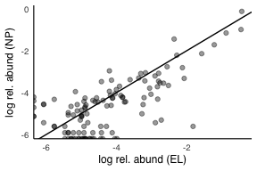

This plot reveals two interesting findings: First, the most abundant taxa are similiarly abundant in both datasets. However, their rank orders are not perfectly conserved. Second, there are many taxa that are barely represented ($\leq 10^{-4}$) that nonetheless occur at modest frequencies in the other dataset. These two cases are Flavobacteriaceae in NPD and Rhizobiales in ELD.

Let’s now compare these abundances with family-level prevalence, to see whether there is a natural cutoff for examining Families more closely:

```r
ELD4 <- merge(ELD3b, EL_fam_prev, by = "Family", sort = F)
ELD4b <- group_by(ELD4, Family) %>% summarise(w_avg_prev = sum(N*prev)/sum(N))
ELD4c <- merge(ELD3b, ELD4b, by = "Family", sort = F)
# now for NP
NPD4 <- merge(NPD3b, NP_fam_prev, by = "Family", sort = F)
NPD4b <- group_by(NPD4, Family) %>% summarise(w_avg_prev = sum(N*prev)/sum(N))
NPD4c <- merge(NPD3b, NPD4b, by = "Family", sort = F)
```

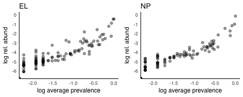

```r
abund_prev_EL <- ggplot(ELD4c, aes(x = log(w_avg_prev,10), y = log(rel_abund,10))) +
  geom_point(alpha = 0.4) +
  scale_y_continuous(limits = c(-6.5,0), breaks = seq(-6,0,1)) + ggtitle("EL") +
  theme_phy1() + xlab("log average prevalence") + ylab("log rel. abund")
abund_prev_NP <- ggplot(NPD4c, aes(x = log(w_avg_prev,10), y = log(rel_abund,10))) +
  geom_point(alpha = 0.4) +
  scale_y_continuous(limits = c(-6.5,0), breaks = seq(-6,0,1)) + ggtitle("NP") +
  theme_phy1() + xlab("log average prevalence") + ylab("log rel. abund")
ggarrange(plotlist = list(abund_prev_EL,abund_prev_NP))
```

## Examining bASV family abundance across leaves

Let’s return to our long-format datasets and sum counts by Family, then plot relative abundance distributions across samples:

```r
## First for EL
ELD_fam <- group_by(ELD3, Row.names, Family) %>% summarise(fam_tot = sum(bASV_count))

# add host and fungal components:
ELD_nonbact <- reshape2::melt(ELD[,names(ELD) %in% c('Row.names','fungi','host')], id.vars = "Row.names", value.name = "fam_tot", variable.name = "Family")

# combine
ELD_fam2 <- rbind(as.data.frame(ELD_fam), ELD_nonbact)
ELD_fam3 <- merge(ELD_fam2, ELD[,names(ELD) %in% c('Row.names', 'herb_dmg','lib')], by = "Row.names", sort = F)
ELD_fam3$rel <- ELD_fam3$fam_tot / ELD_fam3$lib

# re-define levels according to average abundance:
ELD_fam_rank <- group_by(ELD_fam3, Family) %>% summarise(avg_rel = mean(rel)) %>% arrange(desc(avg_rel))
ELD_families <- c('host','fungi',paste0(ELD_fam_rank$Family)[!paste0(ELD_fam_rank$Family) %in% c('host','fungi')])

# re-assign levels of Family
ELD_fam3$Family <- factor(ELD_fam3$Family, levels = ELD_families)

# now re-define levels of samples by total abundance of bASVs in the sample (or by lowest host fraction)
ELD_sample_rank <- filter(ELD_fam3, Family == "host") %>% arrange(desc(fam_tot))

# re-assign factor levels (by decreasing abundance of host-derived 16S counts)
ELD_fam3$Row.names <- factor(ELD_fam3$Row.names, levels = ELD_sample_rank$Row.names)


# bin all low-abundance families into one group:
low_freq_fams <- ELD_fam_rank[ELD_fam_rank$avg_rel < 10^-5, 'Family']

ELD_fam3$Family2 <- ELD_fam3$Family
ELD_fam3$Family2 <- as.character(ELD_fam3$Family2)
ELD_fam3[ELD_fam3$Family %in% paste0(low_freq_fams$Family),'Family2'] <- 'low'


# Now for NP
NPD_fam <- group_by(NPD3, Row.names, Family) %>% summarise(fam_tot = sum(bASV_count))

# add host and fungal components:
NPD_nonbact <- reshape2::melt(NPD[,names(NPD) %in% c('Row.names','fungi','host')], id.vars = "Row.names", value.name = "fam_tot", variable.name = "Family")

# combine
NPD_fam2 <- rbind(as.data.frame(NPD_fam), NPD_nonbact)
NPD_fam3 <- merge(NPD_fam2, NPD[,names(NPD) %in% c('Row.names', 'herb_dmg','lib')], by = "Row.names", sort = F)
NPD_fam3$rel <- NPD_fam3$fam_tot / NPD_fam3$lib

# re-define levels according to average abundance:
NPD_fam_rank <- group_by(NPD_fam3, Family) %>% summarise(avg_rel = mean(rel)) %>% arrange(desc(avg_rel))
NPD_families <- c('host','fungi',paste0(NPD_fam_rank$Family)[!paste0(NPD_fam_rank$Family) %in% c('host','fungi')])

# re-assign levels of Family
NPD_fam3$Family <- factor(NPD_fam3$Family, levels = NPD_families)

# now re-define levels of samples by total abundance of bASVs in the sample (or by lowest host fraction)
NPD_sample_rank <- filter(NPD_fam3, Family == "host") %>% arrange(desc(fam_tot))

# re-assign factor levels (by decreasing abundance of host-derived 16S counts)
NPD_fam3$Row.names <- factor(NPD_fam3$Row.names, levels = NPD_sample_rank$Row.names)


# bin all low-abundance families into one group:
low_freq_fams_NP <- NPD_fam_rank[NPD_fam_rank$avg_rel < 10^-5, 'Family']

NPD_fam3$Family2 <- NPD_fam3$Family
NPD_fam3$Family2 <- as.character(NPD_fam3$Family2)
NPD_fam3[NPD_fam3$Family %in% paste0(low_freq_fams_NP$Family),'Family2'] <- 'low'
```

```r
cat(all_fams, con = f, sep = "\n")
```

```
Pseudomonadaceae
Sphingomonadaceae
Oxalobacteraceae
Microbacteriaceae
Sphingobacteriaceae
Rhizobiales_Incertae_Sedis
Hyphomicrobiaceae
Enterococcaceae
Cytophagaceae
Comamonadaceae
Flavobacteriaceae
Streptococcaceae
Methylobacteriaceae
Enterobacteriaceae
Rhizobiaceae
Paenibacillaceae
4
```

Let’s plot this another way:

```r
fpv2 <- ggplot(dplyr::filter(ELD_fam2,Family %in% fam94), aes(y = Family, x = Row.names, fill = log(fam_tot / host))) +
  geom_tile(na.rm = TRUE) +
  facet_wrap(~herb_dmg, scales = "free_x") +
  scale_fill_gradientn(colors = viridis(20), na.value = "white") +
  xlab("sample") + theme_phy1() +
  theme(axis.text.x = element_blank())

print(fpv2)
```

[output not shown]

Let’s do the same for the NPB dataset:

```r
NP_fam99 <- NPD3b$Family[NPD3b$cum_tot < 0.99]
NP_fam94 <- NPD3b$Family[NPD3b$cum_tot < 0.94]
NPD_fam2$herb_dmg <- factor(NPD_fam2$herb_dmg)

# version 1: barplot with log ratios plotted for each family:
NP_fpv1 <- ggplot(dplyr::filter(NPD_fam2,Family %in% NP_fam99), aes(x = herb_dmg, y = log(fam_tot / host), col = herb_dmg)) + geom_jitter(width = 0.15, alpha = 0.2) +
  geom_boxplot(alpha = 0.2) +
  scale_color_manual(values = c("gray40","dodgerblue")) +
  facet_wrap( ~ Family, ncol = 9, nrow = 1) +
  ylab("ln (bac/host)") + theme_phy1() +
  theme(strip.text = element_text(size = 6),
        legend.position = "none")

print(NP_fpv1)
```

[output not shown]

The next plot I want to see is the standard stacked bar chart of relative abundances, plotted on log scale and linear scales, for all of the top 10 families. To do this, I need to sum up the abundance of all lower OTUs per family and then plot them in a stacked bar format:

```r
# function to collapse bASV by unique.id into higher-level bins (base case is Family).
# script takes a list of families and collapses counts found in x based on taxonomy in y
x <- ELD3
y <- bTAX6 # this should work, as will anything with the taxonomy mapping
fams <-

family_prev_persample <- function(x,y,fams){
  fams2 <- NULL
  for (s in 1:length(fams)){
    focal_asvs <- y$unique.id[y$Family %in% paste0(fams[s])]
    tmp_df <- x[,names(x) %in% focal_asvs]
    if(length(focal_asvs) < 2){
      new_df <- data.frame(fam_tot = sum(tmp_df),herb_dmg = x$herb_dmg)
      new_df$fam_tot[new_df$fam_tot > 0] <- 1 # re-assign to binary for prevalence calculation
      new_df2 <- group_by(new_df, herb_dmg) %>% summarise(hits = sum(fam_tot), N = length(herb_dmg), prev = hits/N)
    } else{
      #new_sums <- rowSums(tmp_df)
      new_df <- data.frame(fam_tot = rowSums(tmp_df),herb_dmg = x$herb_dmg)
      new_df$fam_tot[new_df$fam_tot > 0] <- 1 # re-assign to binary for prevalence calculation
      new_df2 <- group_by(new_df, herb_dmg) %>% summarise(hits = sum(fam_tot), N = length(herb_dmg), prev = hits/N)
    }
    fams2 <- rbind(fams2,data.frame(Family = paste0(fams[s]), new_df2))
  }
  return(fams2)
}
```